# K-means

ZY Fang

11/02/2018

## Problem 3. K-means algorithm

### The algorithm

Here we write a k-means classifier and test it on different data sets. In the algorithm, we run a few iterations with different initial cluster centers, and choose the best result in each iteration with respect to the sum of distance.

The distance between points is Euclidean distance. The distance function is

```r
distance <- function (a, b) {
  dis <- sqrt (sum ((a - b) ^ 2))
  return (dis)
}
```

The algorithm of K-means with given *k* and given starting points is

1. **Initialize** the coordinates of the starting points to be the centers of the *k* clusters.
2. **Check** each data point, if the distance to other cluster center is smaller than the distance to the current cluster center, change this point to the cluster with the nearest center, and update the centers of clusters.
3. **Repeat** step (ii) until no point changes its cluster. The current state is the result.
4. **Return** the labels of cluster that each point belongs to.

The code is showed as follows, together with comment of details.

```r
K_means_fixed_start <- function (k, dataset, starting_points) {
  # The data size
  N <- length (dataset[, 1])

  # The dimension of each data point
  dimension <- length (dataset[1, ])

  # The center of each class
  center <- matrix (nrow = k, ncol = dimension)

  # The sum of coordinates of each class
  coordinate_sum <- matrix (nrow = k, ncol = dimension)

  # The number of points in each class
  cnt <- rep(1, k)

  # The class label for each point
  label <- rep(k + 1, N)

  # Initialize: assign starting_points to be centers of the k classes
  number <- 1
  for (i in starting_points) {
      label[i] <- number
      number <- number + 1
  }
  for (i in 1: N) {
      if (label[i] != k + 1) {
        center[label[i], ] <- dataset[i, ]
        coordinate_sum[label[i], ] <- dataset[i, ]
      }
  }

  # Keep updating clusters and center coodinates
  # until no point changes it cluster
  is_changed <- TRUE
  INF <- 9999999;

  while (is_changed) {
    is_changed = FALSE

    # update the cluster for each point
    for (i in 1: N) {
      if (label[i] <= k)
        min_dis <- distance(dataset[i, ], center[label[i], ])
      else
        min_dis <- INF

    # check the distance to each cluster center
    for (j in 1: k) {
      if (distance(dataset[i, ], center[j, ]) < min_dis) {
        min_dis <- distance(dataset[i, ], center[j, ])

        # if there is a nearer cluster center
        if (j != label[i]) {
          # update cluster center coordinates
          if (label[i] <= k) {
            coordinate_sum[label[i],] <- coordinate_sum[label[i],] - dataset[i,]
            cnt[label[i]] <- cnt[label[i]] - 1
            center[label[i], ] <- coordinate_sum[label[i], ] / cnt[label[i]]
          }

          coordinate_sum[j, ] <- coordinate_sum[j, ] + dataset[i, ]
          cnt[j] <- cnt[j] + 1
          center[j, ] <- coordinate_sum[j, ] / cnt[j]

          # the cluster of this point is changed
          # then keep looping
          is_changed <- TRUE
          label[i] <- j
          }
        }
      }
    }
  }

  # return the labels of cluster that each point belongs to
  return (label)
}
```

Different starting point may result in different cluster result. Which result shall we choose? We measure the result by the sum of distance between each point and their corresponding cluster center.

```r
compute_cluster_error <- function (k, dataset, label) {
  dimension <- length (dataset[1, ])
  N <- length (dataset[, 1])
  coordinate_sum <- matrix (0, nrow = k, ncol = dimension)
  center <- matrix (0, nrow = k, ncol = dimension)
  cnt <- rep(0, k)

  # compute the coordinate of each cluster center
  for (i in 1: N) {
    cnt[label[i]] <- cnt[label[i]] + 1
    coordinate_sum[label[i], ] <- coordinate_sum[label[i], ] + dataset[i, ]
  }
  for (i in 1: k)
    center[i, ] <- coordinate_sum[i, ] / cnt[i]

  # add up the distance
  error <- 0
  for (i in 1: N)
    error = error + sum((dataset[i, ] - center[label[i], ]) ^ 2)

  return (error)
}
```

A good cluster result should be “compact”, thus the sum of distance should be small. Therefore, we compute the sum of distance for each result, and choose the one with the **least** sum of distance.

The following code shows the complete algorithm. We run a few iterations, and in each iteration we generate different starting points. We get the cluster result with funtion *K_means_fixed_start()*, and compute its *cluster_error*, i.e. the sum of distance between each point and its cluster center. Then we choose the result with the least *cluster_error*.

```r
K_means <- function (data.train, k, trials) {
  N <- length (data.train[, 1])
  min_error <- 999999999
  best_ans <- rep (1, N)

  error_list <- c ()

  for (i in 1: trials) {
    starting_points <- sample(1: N, size = k, replace = FALSE)
    label <- K_means_fixed_start (k, as.matrix (data.train), starting_points)
    error <- compute_cluster_error (k, as.matrix (data.train), label)
    if (min_error > error) {
      min_error <- error
      best_ans <- label
    }
  }

  return (best_ans)
}
```

When the true labels are given, we can compare the true labels and our cluster labels to measure the performance of K-means. Since we may not have the same name of each cluster as the true labels, we define the correctness in the following way:

Suppose the data points are $\{X_k\}_{1\leq k\leq N}$, with true labels $\{y_k\}_{1\leq k\leq N}$, and our result of cluster labels are $\{\hat y_k\}_{1\leq k\leq N}$. Then the number of pairs $(X_i,X_j)$ where $1\leq i <j\leq N$ is $\frac{N(N-1)}{2}$. For each pair $(X_i,X_j)$, the true label $y_i=y_j$ means they are in the same cluster. If we have $\hat y_i=\hat y_j$, then our prediction for this pair is correct. Also, the true label $y_i\neq y_j$ means they are in different clusters. If we have $\hat y_i\neq\hat y_j$, then our prediction for this pair is correct.

```r
compute_correctness <- function(my_label, true_label) {
  N <- length(my_label)

  # total number of pairs
  tot <- N * (N - 1) / 2

  # the number of correct pairs we find
  correct <- 0

  for (i in 1: (N - 1))
    for (j in (i + 1): N) {
      # point i and point j are in the same cluster
      if (my_label[i] == my_label[j] && true_label[i] == true_label[j])
        correct <- correct + 1
      # point i and point j are in different clusters
      if (my_label[i] != my_label[j] && true_label[i] != true_label[j])
        correct <- correct + 1
    }

  return (correct / tot)
}
```

### Test

We test our algorithm on rattle project in R. We know in advance that $k = 3$. First we test out algorithm without any preprocess.

```r
library("fpc")
library ("rattle")
```

[output not shown]

```r
data (wine, package = "rattle")
data.train <- wine[-1]
true_label <- as.numeric(wine[, 1])

my_label <- K_means(data.train, k = 3, trials = 20)
compute_correctness(my_label, true_label)
```

```
## [1] 0.7186568
```

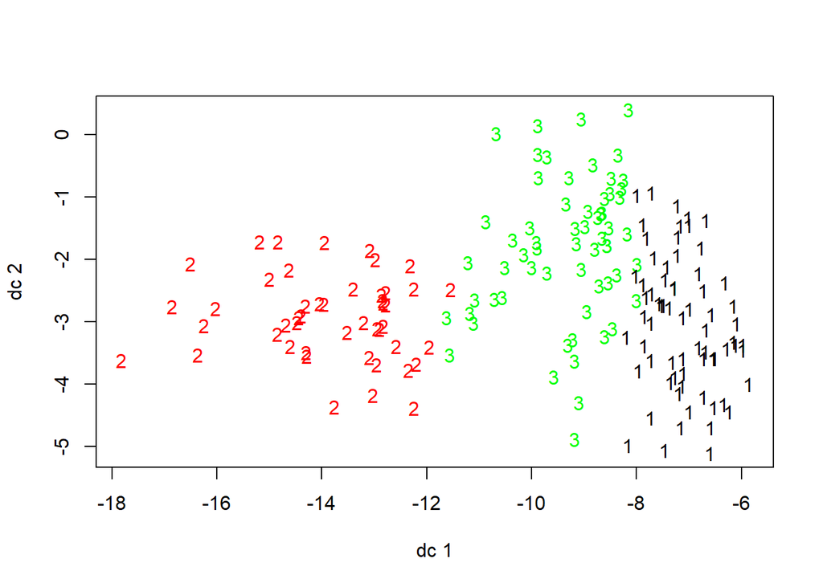

```r
plotcluster(data.train, my_label)
```

The scale of features has a strong influence on our algorithm. Because the features with a big scale contribute a lot to the Euclidean distance, while the small scale features have a much smaller influence on the cluster result. However, when we run clustering algorithm on this data set, there is no reason to believe that features with a big scale should contribute more to the final result than the features with a small scale do. Therefore, we can rescale our data so that each feature contributes to the Euclidean distance in the equal scale.

```r
data.train <- scale(wine[-1])
# this line of code executes a linear transformation to each column
# so that each column (each feature) will be: mean = 0, variance = 1

my_label <- K_means(data.train, k = 3, trials = 20)
compute_correctness(my_label, true_label)
```

```
## [1] 0.9542944
```

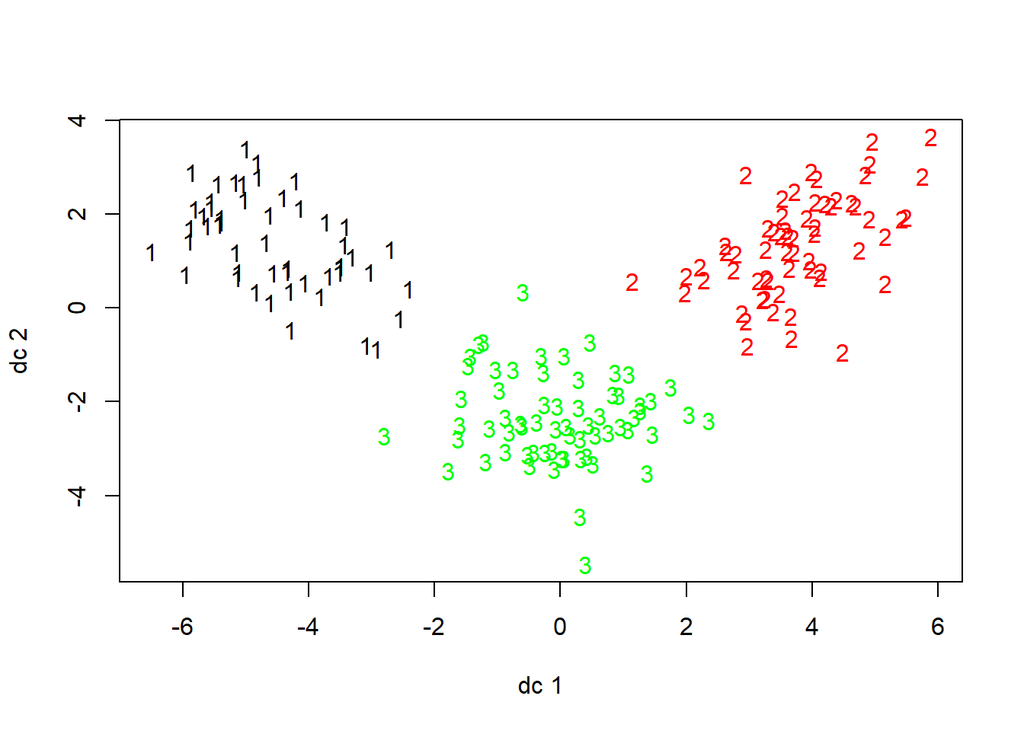

```r
plotcluster(data.train, my_label)
```

We can see that there is a significant improvement in the result. The correct rate exceeds 95%. From the cluster plot we can also see that the three clusters are well separated. It means that the rescaling makes sense and works well.

Then we repeat these steps on *iris* data set. The result of original data is

```r
data(iris)
data.train <- iris[-5]
true_label <- as.numeric(iris[, 5])
k <- 3
my_label <- K_means(data.train, k, trials = 20)
compute_correctness(my_label, true_label)
```

```
## [1] 0.8797315
```

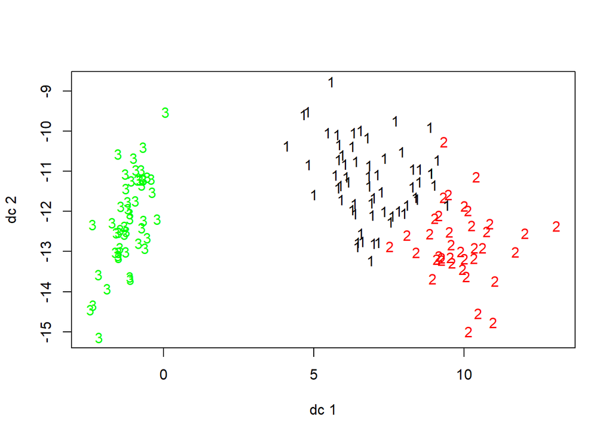

```r
plotcluster(data.train, my_label)
```

And the result of rescaled data

```r
data.train <- scale(iris[-5])
my_label <- K_means(data.train, k, trials = 20)
compute_correctness(my_label, true_label)
```

```
## [1] 0.8322148
```

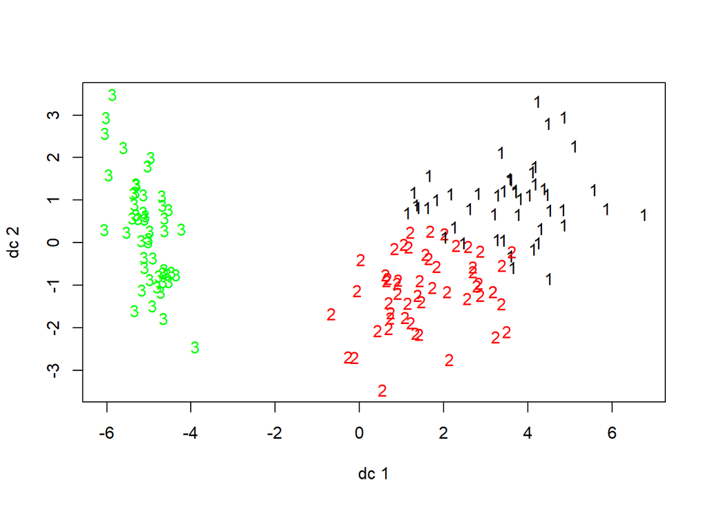

```r
plotcluster(data.train, my_label)
```

The correct rate is above 80%. K-means still works, but not perfect.

It is notable that the result of original data is slightly better than the result of rescaled data, i.e. the rescaling does not work this time.